# White Wine Quality Exploration by Akshat N. Tickoo

This report explores a dataset containing data about different components of wine taken from 4898 wine samples.

# Univariate Plots Section

```
## 'data.frame':    4898 obs. of  13 variables:
##  $ X                   : int  1 2 3 4 5 6 7 8 9 10 ...
##  $ fixed.acidity       : num  7 6.3 8.1 7.2 7.2 8.1 6.2 7 6.3 8.1 ...
##  $ volatile.acidity    : num  0.27 0.3 0.28 0.23 0.23 0.28 0.32 0.27 0.3 0.22 ...
##  $ citric.acid         : num  0.36 0.34 0.4 0.32 0.32 0.4 0.16 0.36 0.34 0.43 ...
##  $ residual.sugar      : num  20.7 1.6 6.9 8.5 8.5 6.9 7 20.7 1.6 1.5 ...
##  $ chlorides           : num  0.045 0.049 0.05 0.058 0.058 0.05 0.045 0.045 0.049 0.044 ...
##  $ free.sulfur.dioxide : num  45 14 30 47 47 30 30 45 14 28 ...
##  $ total.sulfur.dioxide: num  170 132 97 186 186 97 136 170 132 129 ...
##  $ density             : num  1.001 0.994 0.995 0.996 0.996 ...
##  $ pH                  : num  3 3.3 3.26 3.19 3.19 3.26 3.18 3 3.3 3.22 ...
##  $ sulphates           : num  0.45 0.49 0.44 0.4 0.4 0.44 0.47 0.45 0.49 0.45 ...
##  $ alcohol             : num  8.8 9.5 10.1 9.9 9.9 10.1 9.6 8.8 9.5 11 ...
##  $ quality             : int  6 6 6 6 6 6 6 6 6 6 ...
```

```
##        X        fixed.acidity    volatile.acidity  citric.acid
##  Min.   :   1   Min.   : 3.800   Min.   :0.0800   Min.   :0.0000
##  1st Qu.:1225   1st Qu.: 6.300   1st Qu.:0.2100   1st Qu.:0.2700
##  Median :2450   Median : 6.800   Median :0.2600   Median :0.3200
##  Mean   :2450   Mean   : 6.855   Mean   :0.2782   Mean   :0.3342
##  3rd Qu.:3674   3rd Qu.: 7.300   3rd Qu.:0.3200   3rd Qu.:0.3900
##  Max.   :4898   Max.   :14.200   Max.   :1.1000   Max.   :1.6600
##  residual.sugar     chlorides       free.sulfur.dioxide
##  Min.   : 0.600   Min.   :0.00900   Min.   :  2.00
##  1st Qu.: 1.700   1st Qu.:0.03600   1st Qu.: 23.00
##  Median : 5.200   Median :0.04300   Median : 34.00
##  Mean   : 6.391   Mean   :0.04577   Mean   : 35.31
##  3rd Qu.: 9.900   3rd Qu.:0.05000   3rd Qu.: 46.00
##  Max.   :65.800   Max.   :0.34600   Max.   :289.00
##  total.sulfur.dioxide    density             pH          sulphates
##  Min.   :  9.0        Min.   :0.9871   Min.   :2.720   Min.   :0.2200
##  1st Qu.:108.0        1st Qu.:0.9917   1st Qu.:3.090   1st Qu.:0.4100
##  Median :134.0        Median :0.9937   Median :3.180   Median :0.4700
##  Mean   :138.4        Mean   :0.9940   Mean   :3.188   Mean   :0.4898
##  3rd Qu.:167.0        3rd Qu.:0.9961   3rd Qu.:3.280   3rd Qu.:0.5500
##  Max.   :440.0        Max.   :1.0390   Max.   :3.820   Max.   :1.0800
##     alcohol         quality
##  Min.   : 8.00   Min.   :3.000
##  1st Qu.: 9.50   1st Qu.:5.000
##  Median :10.40   Median :6.000
##  Mean   :10.51   Mean   :5.878
##  3rd Qu.:11.40   3rd Qu.:6.000
##  Max.   :14.20   Max.   :9.000
```

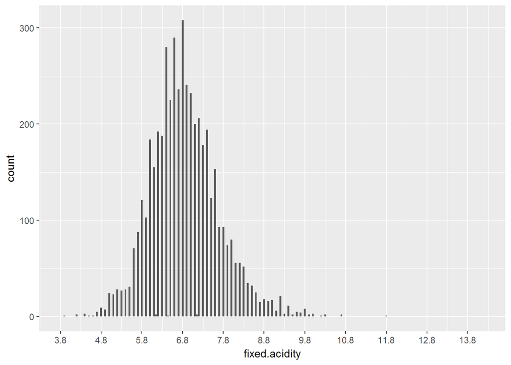

```
##    Min. 1st Qu.  Median    Mean 3rd Qu.    Max.
##   3.800   6.300   6.800   6.855   7.300  14.200
```

```
## 95%
## 8.3
```

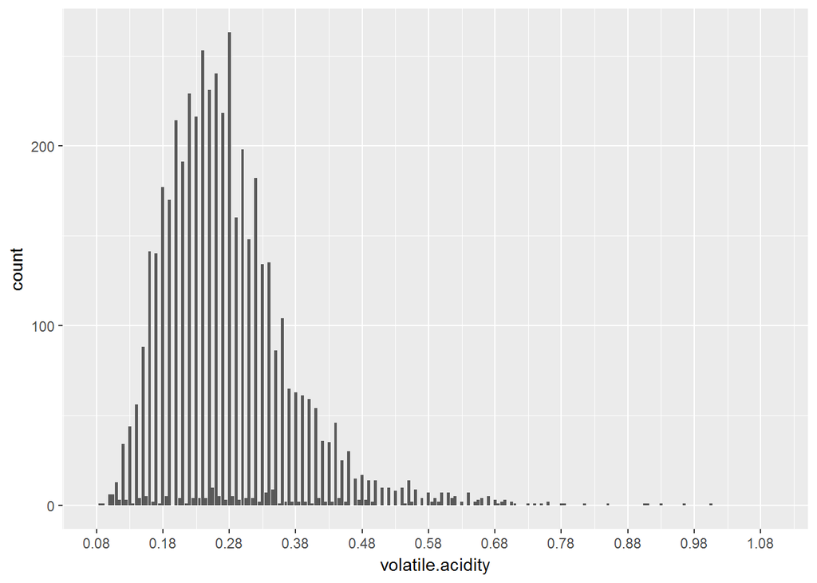

```
##    Min. 1st Qu.  Median    Mean 3rd Qu.    Max.
##  0.0800  0.2100  0.2600  0.2782  0.3200  1.1000
```

```
##  95%
## 0.46
```

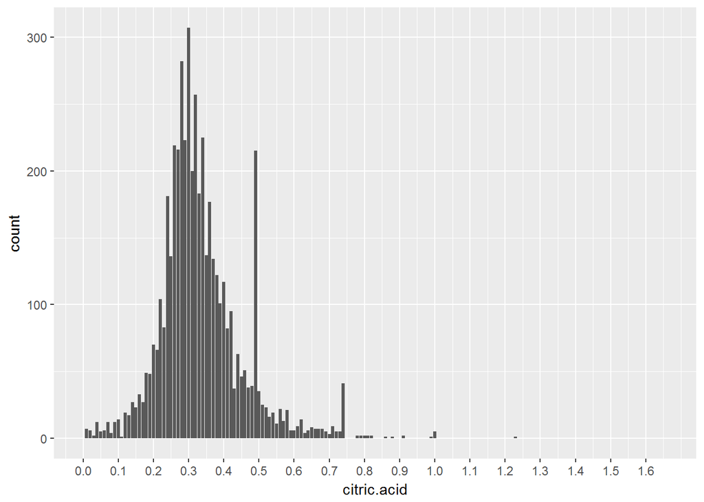

```
##    Min. 1st Qu.  Median    Mean 3rd Qu.    Max.
##  0.0000  0.2700  0.3200  0.3342  0.3900  1.6600
```

```
##  95%
## 0.54
```

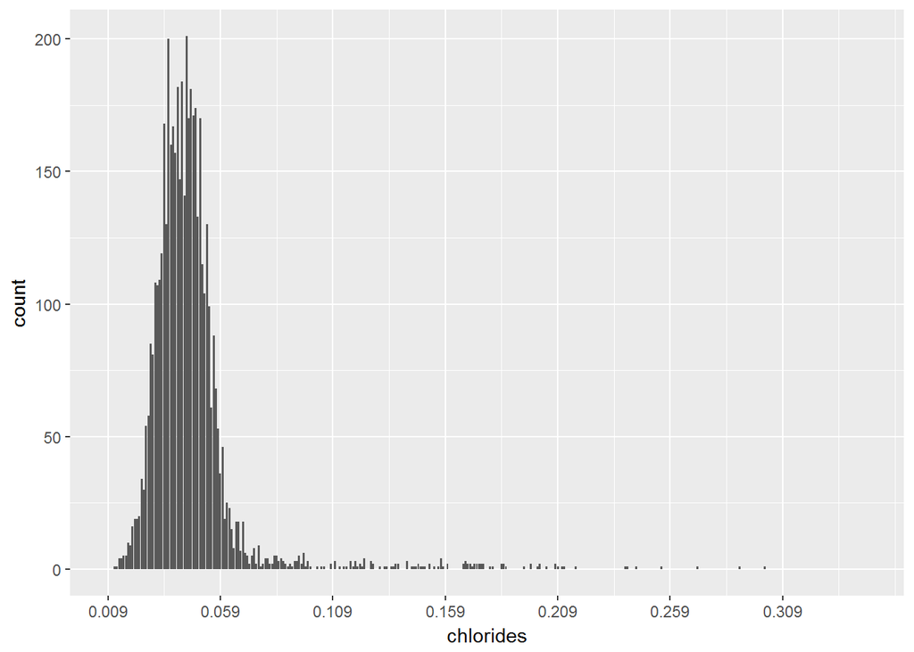

```
##    Min. 1st Qu.  Median    Mean 3rd Qu.    Max.
## 0.00900 0.03600 0.04300 0.04577 0.05000 0.34600
```

```
##   95%
## 0.067
```

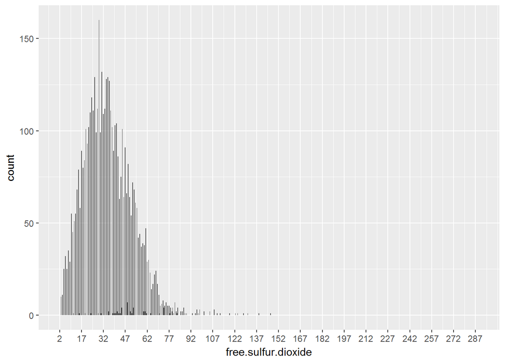

```
##    Min. 1st Qu.  Median    Mean 3rd Qu.    Max.
##    2.00   23.00   34.00   35.31   46.00  289.00
```

```
## 95%
##  63
```

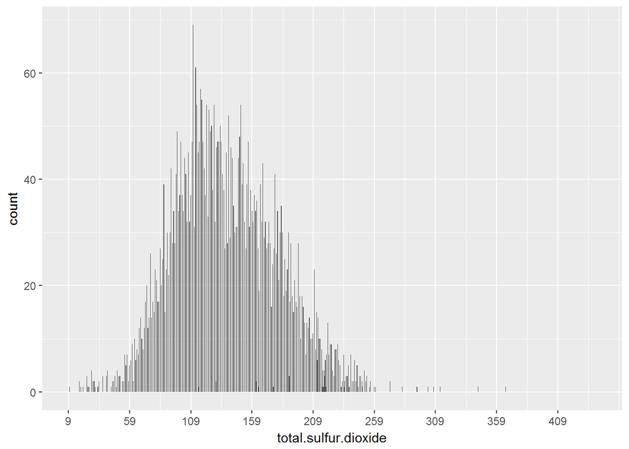

```
##    Min. 1st Qu.  Median    Mean 3rd Qu.    Max.
##     9.0   108.0   134.0   138.4   167.0   440.0
```

```
## 95%
## 212
```

Clearly these 6 variables have outliers as most of them (95%) are within a suitable range. If the outliers are removed we get normal distributions instead of skewed ones as described by the following.

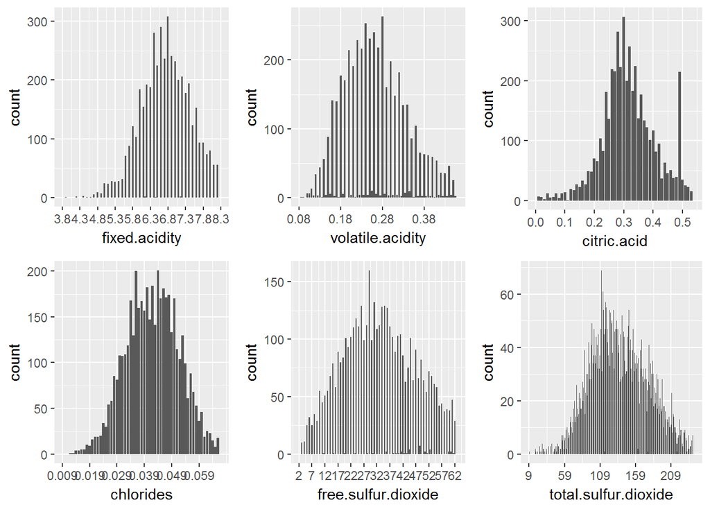

While these four are different in their orientation. Residual Sugar, Sulphates and Alcohol levels are positively skewed while there are some outliers which are quite high in the graph of Density.

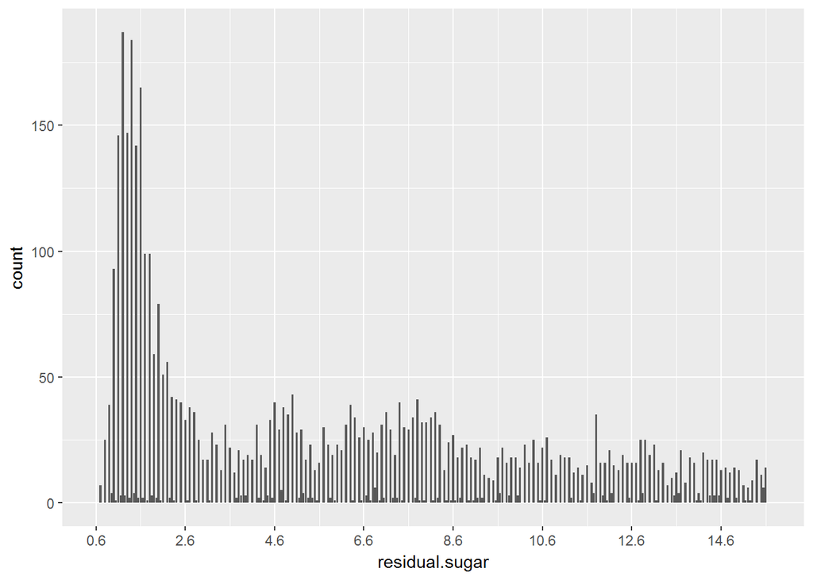

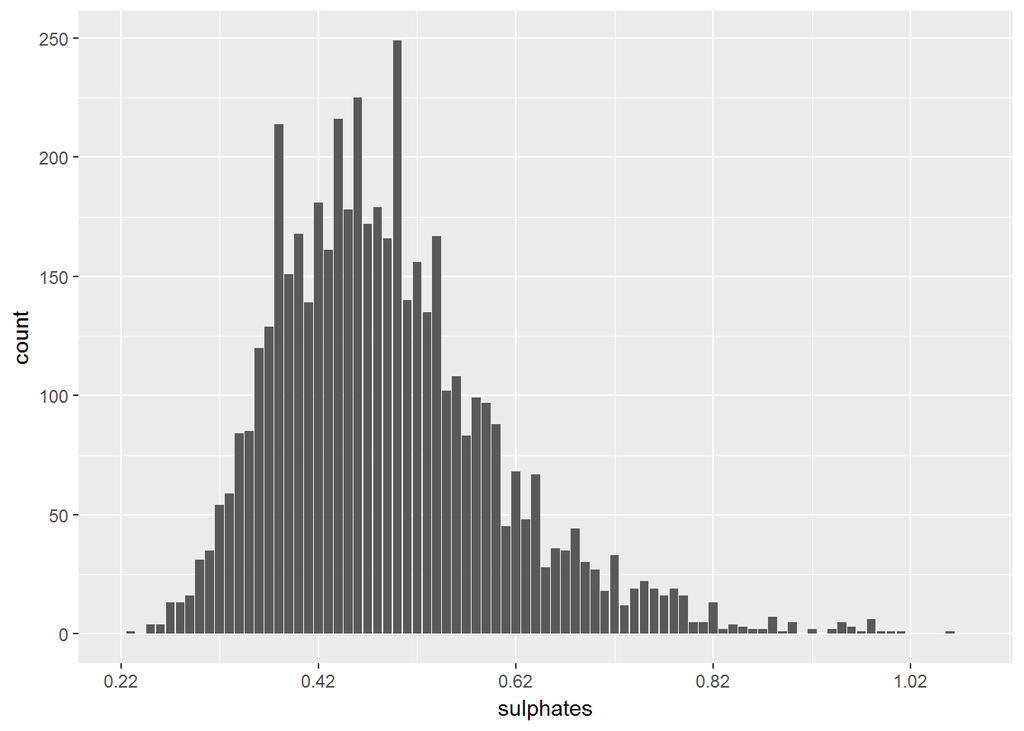

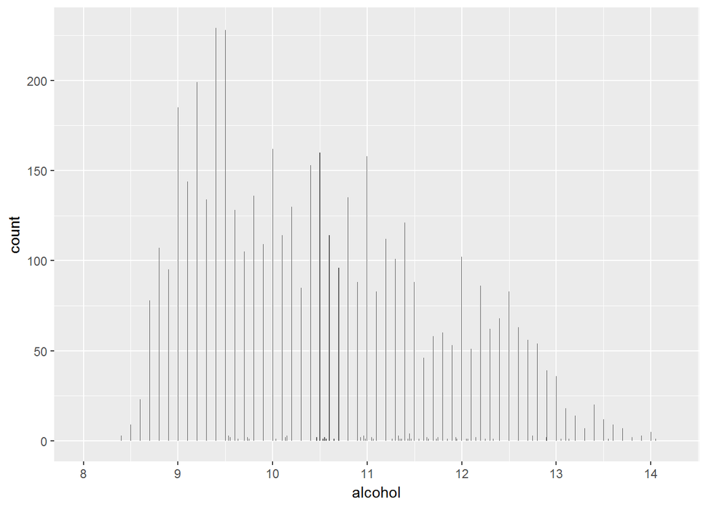

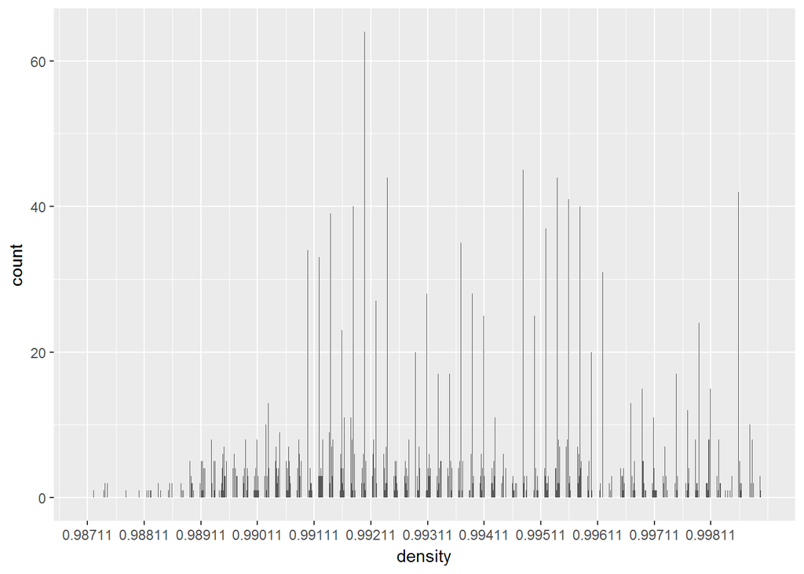

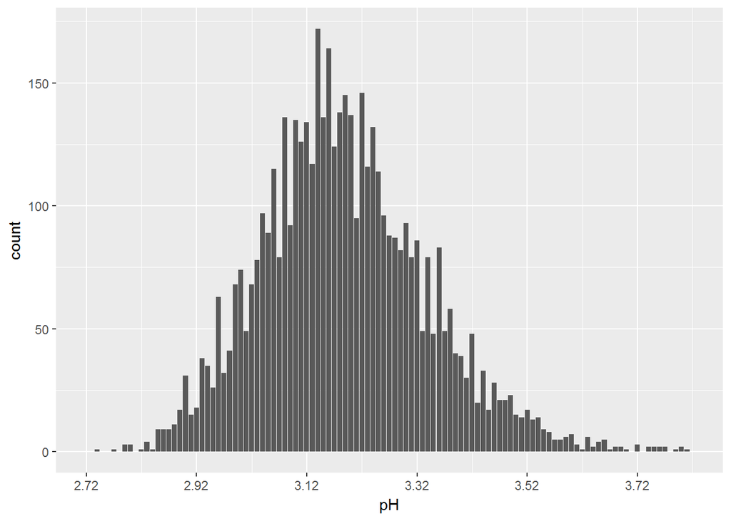

```
##    Min. 1st Qu.  Median    Mean 3rd Qu.    Max.
##   2.720   3.090   3.180   3.188   3.280   3.820
```

```
##  95%
## 3.46
```

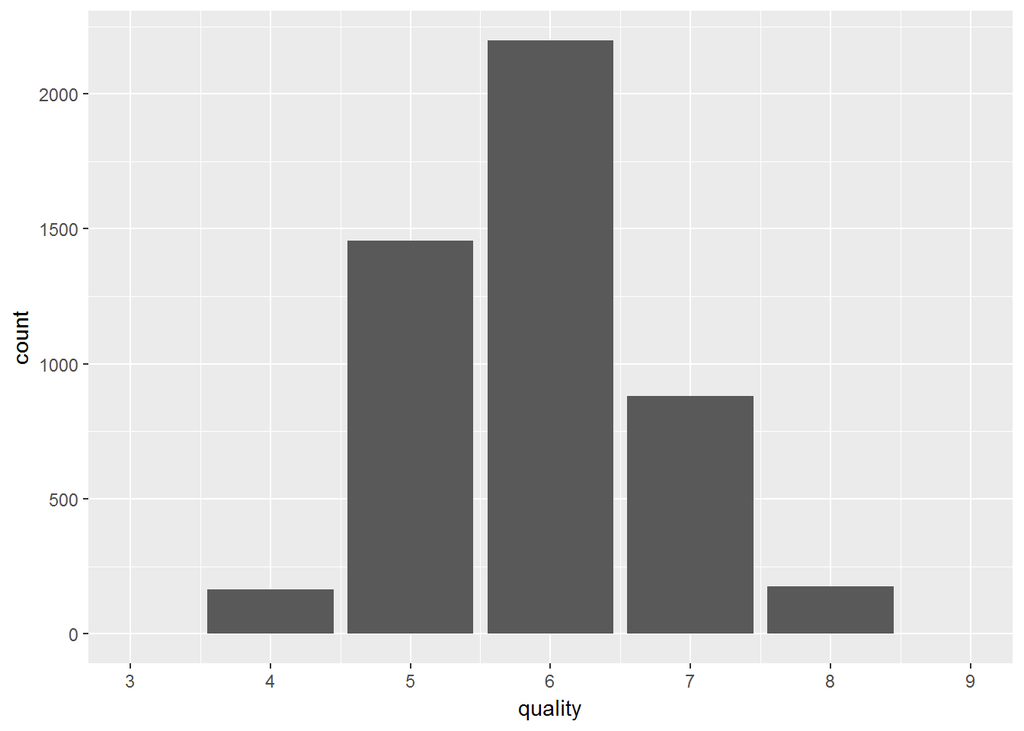

Quite evidently, most of the samples have a quality between 5-7. I’ve made 3 quality levels of the wine depending on their quality score, grouping them into ‘good’, ‘medium’ and ‘bad’.

# Univariate Analysis

### What is the structure of your dataset?

There are 4898 wine samples in this dataset having 12 variables (Fixed Acidity, Volatile Acidity, Citric Acid, Residual Sugar, Chlorides, Free Sulphur Dioxide, Total Sulphur Dioxide, Density, pH level, Sulphates, Alcohol and Quality) all numerical, with most of them being quantities.

### What is/are the main feature(s) of interest in your dataset?

The main features seem to be the acidic levels, the sulphate levels and the alcohol levels.

### What other features in the dataset do you think will help support your investigation into your feature(s) of interest?

The free sulphur dioxide and the total sulphur dioxide can also be of support in further investigation of this dataset.

### Did you create any new variables from existing variables in the dataset?

Yes, I’ve made a variable quality_level, which groups the wines into 3 different types - ‘good’, ‘medium’ and ‘bad’, according to their quality scores.

### Of the features you investigated, were there any unusual distributions? Did you perform any operations on the data to tidy, adjust, or change the form of the data? If so, why did you do this?

Yes, a lot many graphs seemed to be positively skewed when first plotted, but zooming in, we saw that they just have some outliers. Trimming the axis accordingly, and taking into consideration 95% of the values, the graphs on being plotted again seemed to have a normal distribution.

# Bivariate Plots Section

Let’s look at the correlations of all the variables with each other and how strong they are.

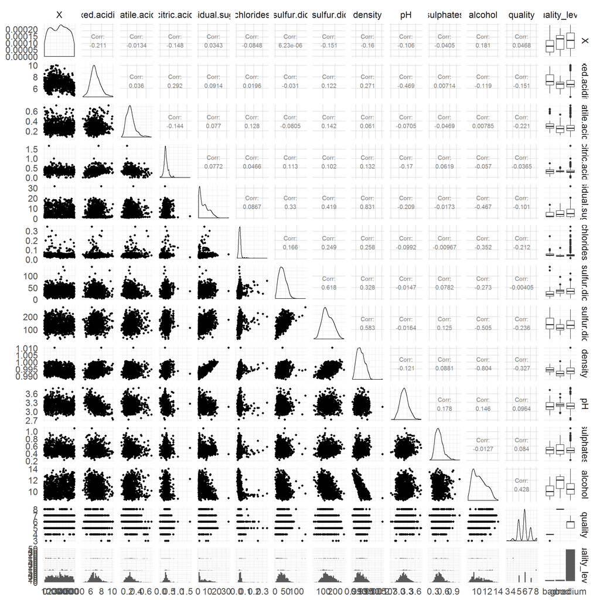

As seen in the above graph, we have the following considerable correlations - 1. Negative 0.469 between pH and fixed acidity. 2. Residual sugar shows correlation with total sulphur dioxide (0.419), a strong correlation with density (0.831) and a negative correlation with alcohol (-0.467). 3. Total sulphur dioxide also shows strong correlations with density (0.583) and alcohol (-0.505). 4. Alcohol then again shows a strong negative correlation with density (-0.804).

So now we’ll have to see how these main features affect the quality scores of the wine samples, one feature at a time!

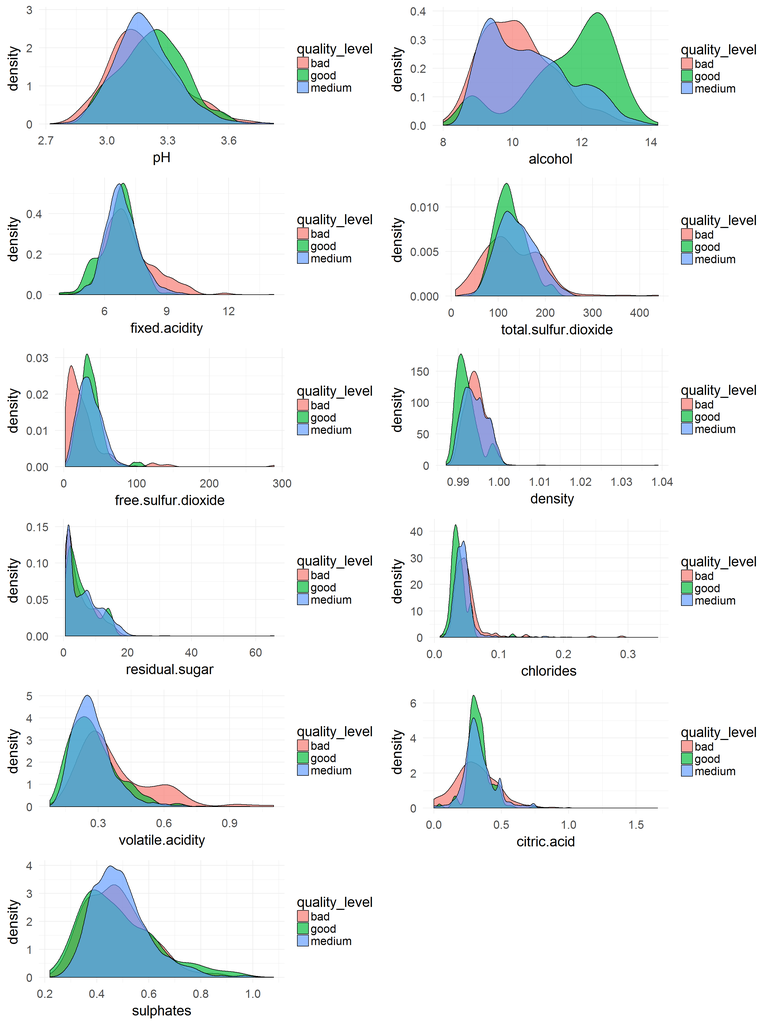

Let’s look at some of these closely using boxplots

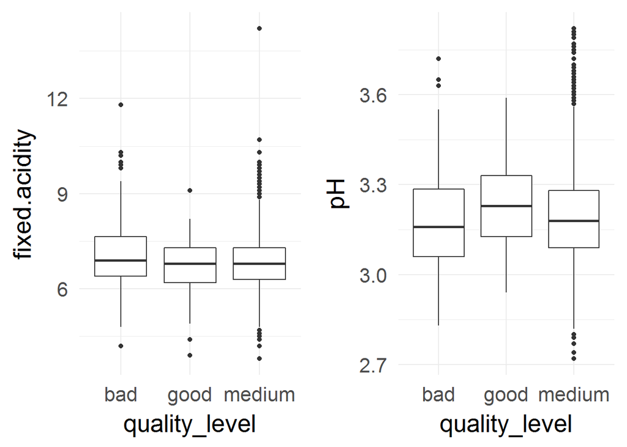

A very loose opposite relation between the two can be seen as confirmed earlier by the correlation coefficient of -0.469.

This also suggests that better quality wines tend to have a slightly higher pH level.

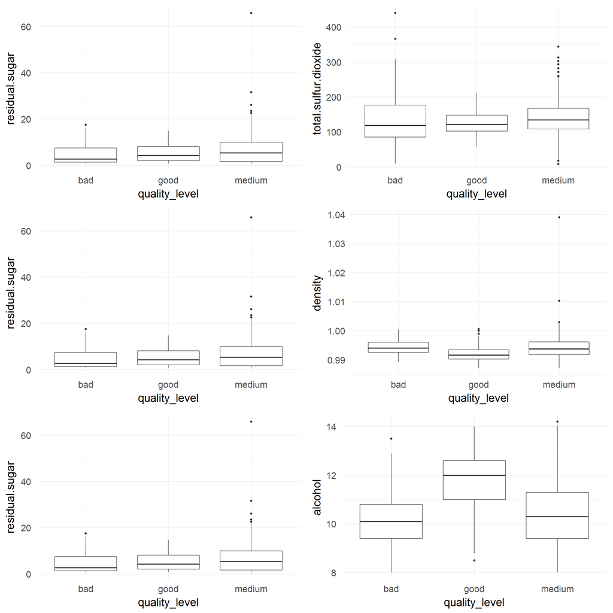

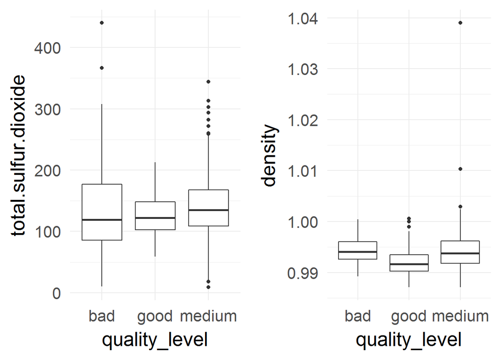

Let’s look at the relation between alcohol and density, as all our graphs yet suggest a strong negative correlation between the two.

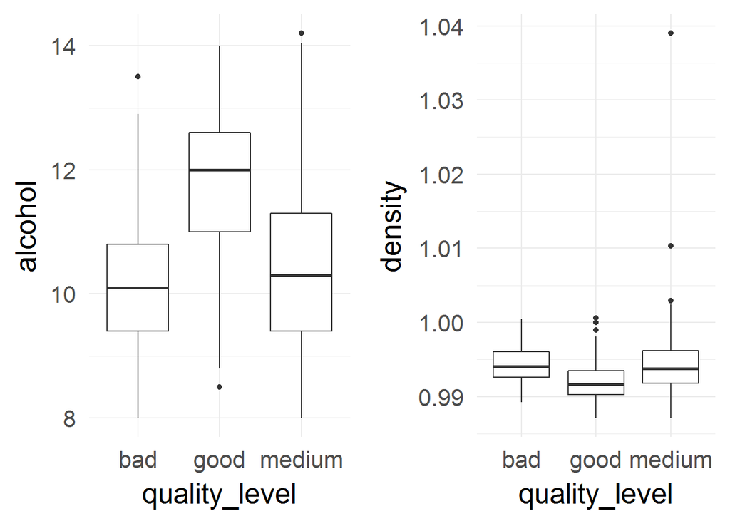

There we have it! As suggested by our calculated score of -0.804.

This graph also suggests that the higher the alcohol content of the wine, the better its quality and vice versa. Similarly, the lower the density of water and sugar content in the wine, the better it tastes.

Let’s look at two other features, whose density plots earlier intrigued me!

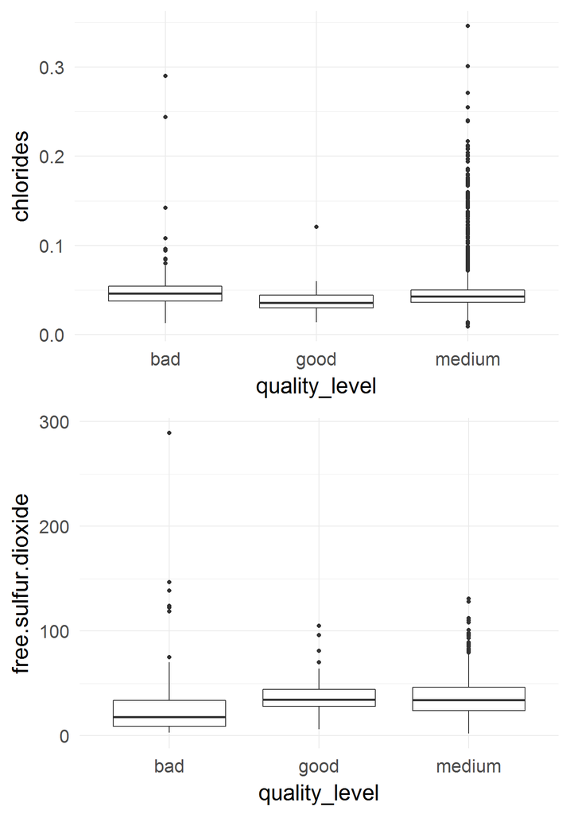

Better quality wines tend to have a slightly lower chloride level. Similarly they tend to have slightly more free sulphur dioxide content in them.

# Bivariate Analysis

### Talk about some of the relationships you observed in this part of the investigation. How did the feature(s) of interest vary with other features in the dataset?

The most important relationship which came into light in this section was that between alcohol content and the quality of wine. Also density and the pH value also does seem to have an effect on the quality.

Rest of the features in the dataset have mostly flat graphs as seen above.

### Did you observe any interesting relationships between the other features (not the main feature(s) of interest)?

Yes as we saw in the last, chlorides and free sulphur dioxide seem to also have minor effects on the quality.

### What was the strongest relationship you found?

The strongest relation is definitely that between the alcohol content and the quality of wine.

# Multivariate Plots Section

So since alcohol is one if the defining features till now, let’s look at it in comparison with other features facet_wraping the quality type.

[output not shown]

[output not shown]

[output not shown]

[output not shown]

[output not shown]

[output not shown]

[output not shown]